# Quiz1

Shubham Gupta

July 31, 2016

You don’t have to seed, caching give the same results as long as cache files aren’t touched

```r
knitr::opts_chunk$set(cache=TRUE)
```

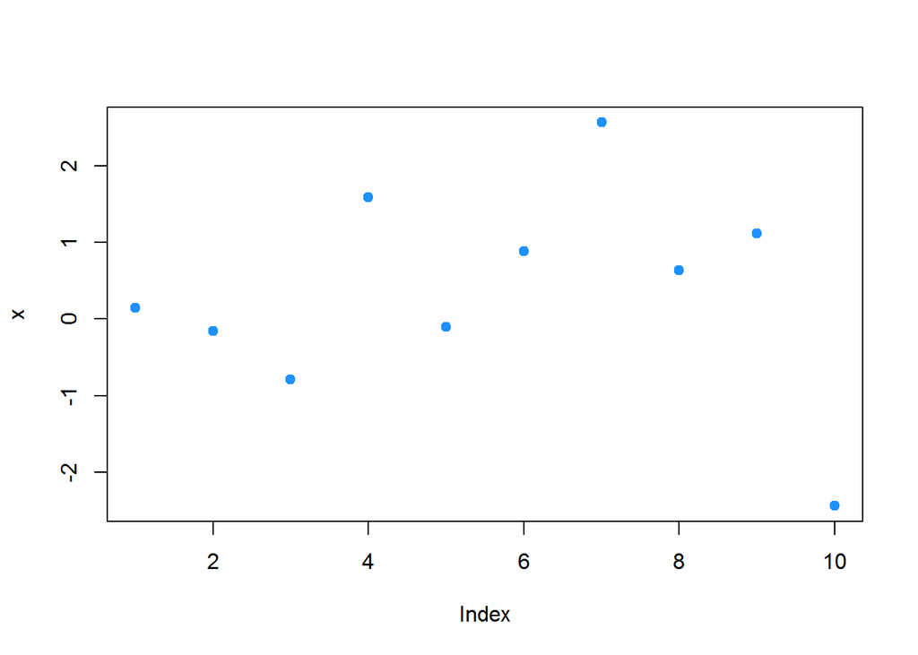

```r
x = rnorm(10)
plot(x,pch=19,col="dodgerblue")
```

```r
y = rbinom(20,size=1,prob=0.5)
table(y)
```

```
## y
##  0  1
## 13  7
```

## What Is Metastatic Cancer?

The main reason that cancer is so serious is its ability to spread in the body. Cancer cells can spread locally by moving into nearby normal tissue. Cancer can also spread regionally, to nearby lymph nodes, tissues, or organs. And it can spread to distant parts of the body. When this happens, it is called metastatic cancer. For many types of cancer, it is also called stage IV (four) cancer. The process by which cancer cells spread to other parts of the body is called metastasis.

When observed under a microscope and tested in other ways, metastatic cancer cells have features like that of the primary cancer and not like the cells in the place where the cancer is found. This is how doctors can tell that it is cancer that has spread from another part of the body.

Metastatic cancer has the same name as the primary cancer. For example, breast cancer that spreads to the lung is called metastatic breast cancer, not lung cancer. It is treated as stage IV breast cancer, not as lung cancer.

Suppose that you have measured ChIP-Seq data from 10 healthy individuals and 10 metastatic cancer patients. For each individual you split the sample into two identical sub-samples and perform the ChIP-Seq experiment on each sub-sample. How can you measure (a) biological variability, (b) technical variability and (c) phenotype variability.

1. By looking at variation across samples from 10 different individuals with cancer or healthy
2. By looking at variability between the measurements on the two sub-samples from the same sample and
3. by comparing the average measurements on the healthy individuals to the measurements on the individuals with cancer

```r
library(Biobase)
con =url("http://bowtie-bio.sourceforge.net/recount/ExpressionSets/bottomly_eset.RData")
load(file=con)
close(con)
bot = bottomly.eset
pdata_bot=pData(bot)
con =url("http://bowtie-bio.sourceforge.net/recount/ExpressionSets/bodymap_eset.RData")
load(file=con)
close(con)
bm = bodymap.eset
pdata_bm=pData(bm)
head(pdata_bm)
```

```
##           sample.id num.tech.reps tissue.type gender age      race
## ERS025098 ERS025098             2     adipose      F  73 caucasian
## ERS025092 ERS025092             2     adrenal      M  60 caucasian
## ERS025085 ERS025085             2       brain      F  77 caucasian
## ERS025088 ERS025088             2      breast      F  29 caucasian
## ERS025089 ERS025089             2       colon      F  68 caucasian
## ERS025082 ERS025082             2       heart      M  77 caucasian
```

```r
head(pdata_bot)
```

```
##           sample.id num.tech.reps   strain experiment.number lane.number
## SRX033480 SRX033480             1 C57BL/6J                 6           1
## SRX033488 SRX033488             1 C57BL/6J                 7           1
## SRX033481 SRX033481             1 C57BL/6J                 6           2
## SRX033489 SRX033489             1 C57BL/6J                 7           2
## SRX033482 SRX033482             1 C57BL/6J                 6           3
## SRX033490 SRX033490             1 C57BL/6J                 7           3
```

```r
summary(pdata_bm)
```

```
##      sample.id  num.tech.reps    tissue.type  gender       age
##  ERS025081: 1   Min.   :2.000   mixture: 3   F   :8   Min.   :19.00
##  ERS025082: 1   1st Qu.:2.000   adipose: 1   M   :8   1st Qu.:55.25
##  ERS025083: 1   Median :2.000   adrenal: 1   NA's:3   Median :62.50
##  ERS025084: 1   Mean   :2.526   brain  : 1            Mean   :60.38
##  ERS025085: 1   3rd Qu.:2.000   breast : 1            3rd Qu.:74.00
##  ERS025086: 1   Max.   :6.000   colon  : 1            Max.   :86.00
##  (Other)  :13                   (Other):11            NA's   :3
##                race
##  african_american: 1
##  caucasian       :18
##
##
##
##
##
```

```r
summary(pdata_bot)
```

```
##      sample.id  num.tech.reps      strain   experiment.number
##  SRX033472: 1   Min.   :1     C57BL/6J:10   Min.   :4.000
##  SRX033473: 1   1st Qu.:1     DBA/2J  :11   1st Qu.:4.000
##  SRX033474: 1   Median :1                   Median :6.000
##  SRX033475: 1   Mean   :1                   Mean   :5.667
##  SRX033476: 1   3rd Qu.:1                   3rd Qu.:7.000
##  SRX033478: 1   Max.   :1                   Max.   :7.000
##  (Other)  :15
##   lane.number
##  Min.   :1.000
##  1st Qu.:2.000
##  Median :5.000
##  Mean   :4.571
##  3rd Qu.:7.000
##  Max.   :8.000
##
```

```r
is.na(pdata_bm$tissue.type)
```

```
##  [1] FALSE FALSE FALSE FALSE FALSE FALSE FALSE FALSE FALSE FALSE FALSE
## [12] FALSE FALSE FALSE FALSE FALSE FALSE FALSE FALSE
```

```r
sum(is.na(pdata_bm$tissue.type))
```

```
## [1] 0
```

```r
sum(is.na(pdata_bot$strain))
```

```
## [1] 0
```

```r
dim(pdata_bm)
```

```
## [1] 19  6
```

```r
dim(pdata_bot)
```

```
## [1] 21  5
```

the Bottomly data set is likely a better experimental design than the Bodymap data because the number of technical replicates in the Bodymap data varies, but the number in the Bottomly data is consistent.

http://stackoverflow.com/questions/1474081/how-do-i-install-an-r-package-from-source

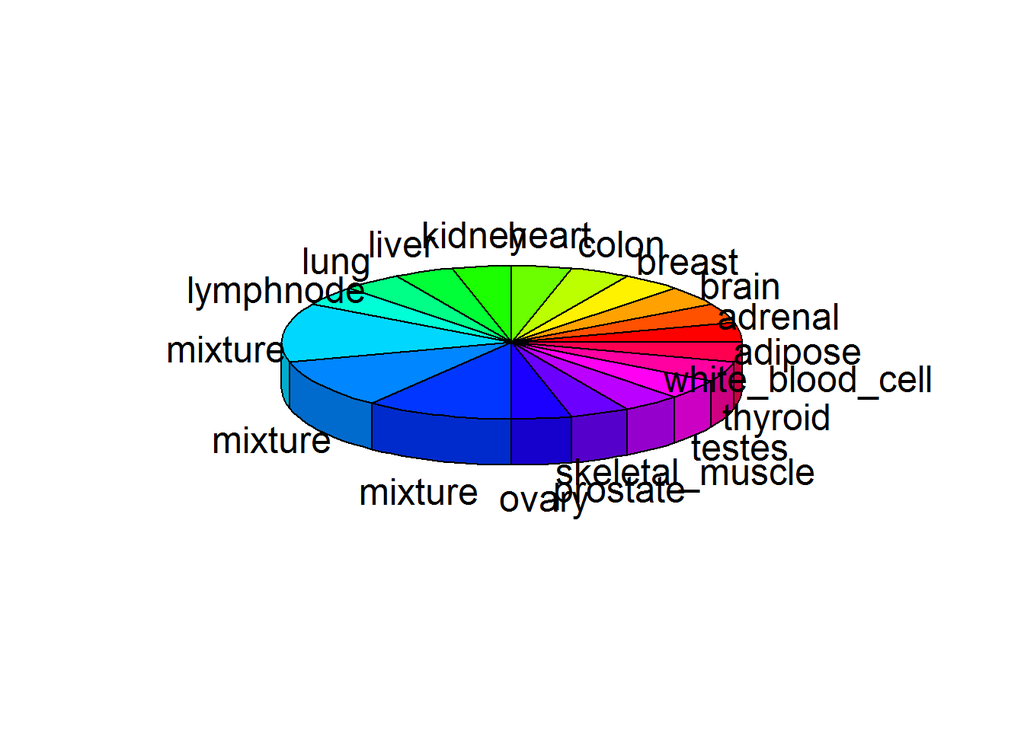

```r
con =url("http://bowtie-bio.sourceforge.net/recount/ExpressionSets/bodymap_eset.RData")
load(file=con)
close(con)
bm = bodymap.eset
pdata_bm=pData(bm)

library(plotrix)
pie3D(pdata_bm$num.tech.reps,labels=pdata_bm$tissue.type)
```

Load Montgomery and Pickrell eset

```r
con =url("http://bowtie-bio.sourceforge.net/recount/ExpressionSets/montpick_eset.RData")
load(file=con)
close(con)
mp = montpick.eset
pdata=pData(mp)
edata=as.data.frame(exprs(mp))
fdata = fData(mp)
```

[output not shown]

[output not shown]

[output not shown]

### Last compilation

Last compiled at 2016-08-05.